# Marketing Incrementality Analysis

Final analytical report

34 DMAs, 18 months, 2025-02-01 through 2026-07-01

## Executive Summary

Production-valid DMAs

7

used in aggregate causal analysis

Aggregate incremental traffic

-352,793

posterior mean

P(aggregate impact > 0)

40.7%

posterior probability

Counterfactual mean R²

0.972

across validated DMAs

Across the 7 production-valid DMAs, the BSTS analysis estimates -352,793 incremental traffic visits relative to the modeled counterfactual. The 95% credible interval ranges from -3,613,360 to 2,865,478, and the posterior probability of a positive aggregate effect is 40.7%.

Marketing-spend robustness shows a suggestive positive linear association between absolute spend increases and estimated incremental traffic (Pearson r=0.850, p=0.015). The corresponding rank-based relationship is materially weaker, so the evidence does not establish a stable monotonic spend-response relationship.

DMA-level placebo tests provide an additional robustness check: 81.0% of placebo impact intervals cross zero. A common-universe aggregate placebo benchmark was not feasible because the available placebo models did not produce a stable common DMA universe across placebo dates.

**Interpretation:** The results support a nuanced DMA-level incrementality story rather than a single precise portfolio-wide effect. Point estimates are informative, but credible intervals and the short historical window materially limit precision.

## Methodology and analytical design

The analysis was designed as a staged incrementality workflow rather than a single-model exercise. The pipeline first established the data panel and exploratory relationships, then examined temporal association, panel regression, and difference-in-differences evidence before moving to DMA-specific Bayesian structural time-series models.

The BSTS specification uses a standardized target, deterministic trend, standardized control-DMA predictors, optional Fourier seasonality, and Gaussian observation noise. Models were fitted only on the pre-treatment period and then propagated across the full modeling horizon using the observed control-DMA trajectories.

Treatment impact is defined as observed post-treatment traffic minus the posterior counterfactual traffic trajectory. Credible intervals are calculated from posterior impact draws directly rather than by combining marginal interval bounds.

## Earlier analytical evidence

### Cross-correlation

The cross-correlation analysis was used to characterize temporal alignment and to compare raw versus detrended relationships. Because trend can induce misleading correlation, the detrended results are the more informative diagnostic for timing rather than a causal estimate.

| Series | Peak Lag | Peak Correlation |
| --- | --- | --- |
| Raw | 0.0 | 0.629 |
| Detrended | 0.0 | 0.589 |

### Panel regression

The panel regression provides a complementary association model that controls for DMA and time effects. It is useful as triangulation, but the BSTS counterfactuals provide the primary treatment-effect estimates.

| Model | Spend Coefficient | Spend P-Value | R-Squared | Observations |
| --- | --- | --- | --- | --- |
| Pooled OLS | 2.570 | 0.0 | 0.496 | 612.0 |
| DMA Fixed Effects | 0.520 | 0.0 | 0.194 | 612.0 |
| DMA + Time Fixed Effects | 0.344 | 0.0 | 0.172 | 612.0 |

### Difference-in-differences

The DiD analysis provides another benchmark for the treatment effect, subject to the quality of the parallel-trends assumption and treatment-group definition.

| Metric | Value |
| --- | --- |
| Treatment Change | 3717.538 |
| Control Change | 9469.542 |
| Difference-in-Differences | -5752.004 |

## BSTS model and counterfactual validation

The production BSTS models passed convergence validation for **7 of 9** modeled DMAs. The counterfactual validation passed for **9 of 9** DMA models.

Mean pre-treatment R² across the validated counterfactuals was **0.972**, indicating close reproduction of the pre-treatment traffic trajectory. Mean 95% interval coverage was **92.9%**.

These diagnostics support using the fitted models for treatment-effect estimation, while the short pre-treatment window remains an important limitation on the precision and stability of causal inference.

## Aggregate causal impact

Estimated incremental traffic

-352,793

posterior mean

95% credible interval

-3,613,360 to 2,865,478

aggregate treatment effect

P(impact > 0)

40.7%

posterior probability

Relative lift

-0.5%

posterior mean

At the portfolio level, the posterior mean indicates a negative traffic effect. However, the credible interval is wide and crosses zero, so the aggregate result should not be interpreted as definitive evidence of a portfolio-wide traffic decline.

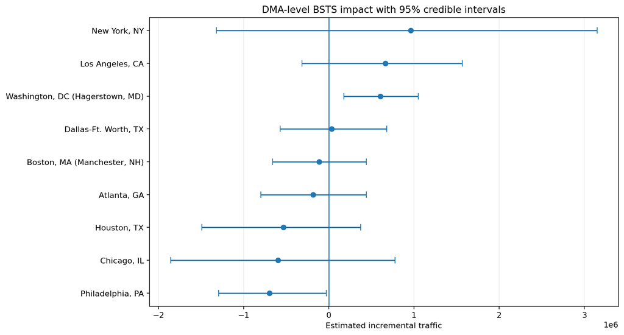

DMA-level BSTS impacts and 95% credible intervals

| DMAs_Included | DMAs_Excluded | Posterior_Draws | Observed_Traffic | Counterfactual_Traffic_Mean | Counterfactual_Traffic_Median | Counterfactual_Traffic_Lower_95 | Counterfactual_Traffic_Upper_95 | Incremental_Traffic_Mean | Incremental_Traffic_Median | Impact_Lower_95 | Impact_Upper_95 | Probability_Positive | Probability_Negative | Relative_Lift_Mean | Relative_Lift_Median | Relative_Lift_Lower_95 | Relative_Lift_Upper_95 | Relative_Lift_Valid_Fraction |
| --- | --- | --- | --- | --- | --- | --- | --- | --- | --- | --- | --- | --- | --- | --- | --- | --- | --- | --- |
| 7 | 2 | 8000 | 59949740.0 | 60302533.282 | 60306692.747 | 57084262.037 | 63563100.016 | -352793.282 | -356952.747 | -3613360.016 | 2865477.963 | 0.407 | 0.593 | -0.005 | -0.006 | -0.057 | 0.05 | 1.0 |

## DMA-level heterogeneity

DMA-level posterior evidence is heterogeneous. The following DMAs have 95% impact intervals that exclude zero: **Philadelphia, PA**.

| DMA | Incremental_Traffic_Mean | Incremental_Traffic_Median | Impact_Lower_95 | Impact_Upper_95 | Probability_Positive | Probability_Negative | Relative_Lift_Mean | Relative_Lift_Median | Relative_Lift_Lower_95 | Relative_Lift_Upper_95 | Absolute_Impact_Mean | Impact_Direction | Model_Valid | Counterfactual_Valid | pre_r2 | pre_rmse_ratio | pre_mae_ratio | pre_coverage_95 | pre_mean_bias_ratio | counterfactual_valid | Impact_Excludes_Zero | Impact_Credible_Direction | Strong_Positive_Evidence | Strong_Negative_Evidence | Posterior_Direction | Impact_Interval_Width | Relative_Lift_Interval_Width | Absolute_Impact_Rank | Impact_Pool | … |
| --- | --- | --- | --- | --- | --- | --- | --- | --- | --- | --- | --- | --- | --- | --- | --- | --- | --- | --- | --- | --- | --- | --- | --- | --- | --- | --- | --- | --- | --- | --- |
| New York, NY | 963299.091 | 980620.508 | -1317675.599 | 3151633.196 | 0.814 | 0.186 | 0.054 | 0.051 | -0.061 | 0.184 | 1211407.676 | Positive | True | True | 0.970 | 0.025 | 0.023 | 1.000 | 0.0 | True | False | Inconclusive | False | False | Inconclusive | 4469308.795 | 0.245 | 1 | Positive | … |
| Chicago, IL | -597896.806 | -622452.717 | -1856604.340 | 778068.884 | 0.183 | 0.817 | -0.069 | -0.079 | -0.204 | 0.120 | 745281.824 | Negative | True | True | 0.971 | 0.042 | 0.034 | 0.909 | 0.0 | True | False | Inconclusive | False | False | Inconclusive | 2634673.223 | 0.324 | 2 | Negative | … |
| Philadelphia, PA | -698524.387 | -708481.940 | -1292849.392 | -29386.765 | 0.021 | 0.979 | -0.121 | -0.125 | -0.207 | -0.006 | 706296.100 | Negative | True | True | 0.986 | 0.023 | 0.020 | 0.909 | 0.0 | True | True | Negative | False | True | Negative | 1263462.627 | 0.201 | 3 | Negative | … |
| Los Angeles, CA | 664229.658 | 683786.091 | -315018.293 | 1569172.741 | 0.919 | 0.081 | 0.070 | 0.069 | -0.029 | 0.174 | 706008.531 | Positive | True | True | 0.981 | 0.024 | 0.021 | 0.909 | 0.0 | True | False | Inconclusive | False | False | Inconclusive | 1884191.034 | 0.203 | 4 | Positive | … |
| Houston, TX | -532485.581 | -520859.131 | -1491028.785 | 374193.181 | 0.121 | 0.879 | -0.070 | -0.072 | -0.183 | 0.059 | 589563.018 | Negative | True | True | 0.950 | 0.045 | 0.036 | 0.909 | 0.0 | True | False | Inconclusive | False | False | Inconclusive | 1865221.966 | 0.242 | 5 | Negative | … |
| Atlanta, GA | -184005.045 | -181964.427 | -800638.647 | 441178.743 | 0.270 | 0.730 | -0.036 | -0.040 | -0.156 | 0.114 | 291043.592 | Negative | True | True | 0.919 | 0.046 | 0.035 | 0.818 | 0.0 | True | False | Inconclusive | False | False | Inconclusive | 1241817.390 | 0.270 | 6 | Negative | … |
| Dallas-Ft. Worth, TX | 32589.788 | 23500.780 | -571755.948 | 681439.019 | 0.533 | 0.467 | 0.008 | 0.004 | -0.088 | 0.129 | 243255.947 | Positive | True | True | 0.990 | 0.020 | 0.018 | 1.000 | 0.0 | True | False | Inconclusive | False | False | Inconclusive | 1253194.967 | 0.217 | 7 | Positive | … |

### DMA contribution context

| DMA | Incremental_Traffic_Mean | Incremental_Traffic_Median | Impact_Lower_95 | Impact_Upper_95 | Probability_Positive | Probability_Negative | Contribution_Share_Mean | Contribution_Share_Median | Contribution_Share_Lower_95 | Contribution_Share_Upper_95 | Contribution_Share_Valid_Fraction | Absolute_Impact_Mean | Relative_Lift_Median | Impact_Direction | Model_Valid | Counterfactual_Valid | Impact_Rank | Absolute_Impact_Rank | Contribution_Rank |
| --- | --- | --- | --- | --- | --- | --- | --- | --- | --- | --- | --- | --- | --- | --- | --- | --- | --- | --- | --- |
| New York, NY | 963299.091 | 980620.508 | -1317675.599 | 3151633.196 | 0.814 | 0.186 | 2.704 | 0.208 | -12.700 | 12.900 | 1.0 | 1211407.676 | 0.051 | Positive | True | True | 1 | 1 | 1 |
| Los Angeles, CA | 664229.658 | 683786.091 | -315018.293 | 1569172.741 | 0.919 | 0.081 | 0.589 | -0.078 | -7.993 | 7.789 | 1.0 | 706008.531 | 0.069 | Positive | True | True | 2 | 4 | 2 |
| Dallas-Ft. Worth, TX | 32589.788 | 23500.780 | -571755.948 | 681439.019 | 0.533 | 0.467 | 0.304 | 0.030 | -2.382 | 2.290 | 1.0 | 243255.947 | 0.004 | Positive | True | True | 3 | 7 | 3 |
| Atlanta, GA | -184005.045 | -181964.427 | -800638.647 | 441178.743 | 0.270 | 0.730 | -0.119 | 0.073 | -2.621 | 3.029 | 1.0 | 291043.592 | -0.040 | Negative | True | True | 4 | 6 | 4 |
| Houston, TX | -532485.581 | -520859.131 | -1491028.785 | 374193.181 | 0.121 | 0.879 | -0.187 | 0.190 | -5.969 | 5.629 | 1.0 | 589563.018 | -0.072 | Negative | True | True | 5 | 5 | 5 |
| Philadelphia, PA | -698524.387 | -708481.940 | -1292849.392 | -29386.765 | 0.021 | 0.979 | -0.524 | 0.271 | -7.017 | 7.594 | 1.0 | 706296.100 | -0.125 | Negative | True | True | 7 | 3 | 6 |
| Chicago, IL | -597896.806 | -622452.717 | -1856604.340 | 778068.884 | 0.183 | 0.817 | -1.767 | 0.308 | -6.704 | 7.090 | 1.0 | 745281.824 | -0.079 | Negative | True | True | 6 | 2 | 7 |

## Placebo robustness

The placebo analysis produced **42** valid DMA-by-date tests across **24** DMAs and **3** placebo dates.

Placebo intervals crossed zero in **81.0%** of tests, with strong positive posterior evidence in **21.4%** and strong negative evidence in **4.8%**.

This supports using placebo tests primarily as a DMA-level robustness check. The data did not support a stable common DMA universe across placebo dates, so an aggregate placebo benchmark was not treated as a production inference.

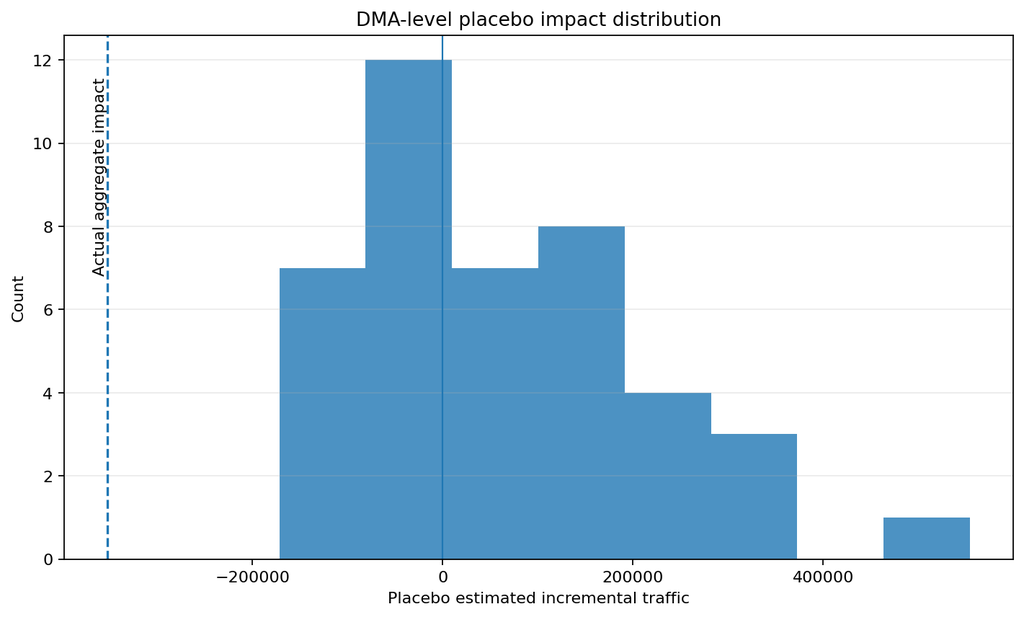

Distribution of DMA-level placebo impact estimates

| DMA | Placebo_Date | Actual_Intervention_Date | Pre_Treatment_Months | Placebo_Post_Months | Selected_Controls | Incremental_Traffic_Mean | Incremental_Traffic_Median | Impact_Lower_95 | Impact_Upper_95 | Probability_Positive | Probability_Negative | Relative_Lift_Median | Counterfactual_Valid | Model_Divergences | Model_Divergence_Rate |
| --- | --- | --- | --- | --- | --- | --- | --- | --- | --- | --- | --- | --- | --- | --- | --- |
| Oklahoma City, OK | 2025-08-01 | 2026-01-01 | 6 | 5 | 1 | 339568.200 | 340313.343 | 251656.183 | 428070.433 | 1.000 | 0.000 | 0.503 | True | 0 | 0.0 |
| Oklahoma City, OK | 2025-10-01 | 2026-01-01 | 8 | 3 | 1 | 240286.150 | 240455.731 | 155734.063 | 322219.670 | 1.000 | 0.000 | 0.529 | True | 0 | 0.0 |
| El Paso, TX (Las Cruces, NM) | 2025-10-01 | 2026-01-01 | 8 | 3 | 1 | 129885.926 | 128403.457 | 52757.257 | 213174.124 | 0.999 | 0.001 | 0.120 | True | 0 | 0.0 |
| Charlotte, NC | 2025-09-01 | 2026-01-01 | 7 | 4 | 1 | 165241.176 | 165993.056 | 70315.119 | 260298.371 | 0.999 | 0.001 | 0.152 | True | 0 | 0.0 |
| Oklahoma City, OK | 2025-09-01 | 2026-01-01 | 7 | 4 | 1 | 217680.476 | 217599.852 | 82756.087 | 351338.063 | 0.999 | 0.001 | 0.368 | True | 0 | 0.0 |
| Cincinnati, OH | 2025-08-01 | 2026-01-01 | 6 | 5 | 1 | 105783.956 | 104183.525 | 1110.073 | 221197.492 | 0.976 | 0.024 | 0.122 | True | 0 | 0.0 |
| Orlando-Daytona Beach-Melbourne, FL | 2025-10-01 | 2026-01-01 | 8 | 3 | 1 | 295429.869 | 302336.461 | -41115.495 | 604186.860 | 0.961 | 0.039 | 0.141 | True | 0 | 0.0 |
| Washington, DC (Hagerstown, MD) | 2025-09-01 | 2026-01-01 | 7 | 4 | 1 | 324510.989 | 324326.724 | -48661.027 | 698572.136 | 0.954 | 0.046 | 0.148 | True | 0 | 0.0 |
| Philadelphia, PA | 2025-10-01 | 2026-01-01 | 8 | 3 | 1 | 175534.723 | 176598.683 | -35596.818 | 378138.011 | 0.954 | 0.046 | 0.073 | True | 0 | 0.0 |
| Puerto Rico | 2025-09-01 | 2026-01-01 | 7 | 4 | 1 | 554382.609 | 549980.094 | -176235.704 | 1280686.590 | 0.928 | 0.072 | 0.104 | True | 0 | 0.0 |
| Boston, MA (Manchester, NH) | 2025-10-01 | 2026-01-01 | 8 | 3 | 1 | 123985.678 | 130090.271 | -68408.703 | 288425.236 | 0.910 | 0.090 | 0.077 | True | 0 | 0.0 |
| Philadelphia, PA | 2025-09-01 | 2026-01-01 | 7 | 4 | 1 | 184117.165 | 188490.973 | -121736.795 | 463664.543 | 0.904 | 0.096 | 0.062 | True | 0 | 0.0 |
| Orlando-Daytona Beach-Melbourne, FL | 2025-09-01 | 2026-01-01 | 7 | 4 | 1 | 249828.976 | 254584.331 | -168943.216 | 656663.939 | 0.874 | 0.126 | 0.093 | True | 0 | 0.0 |
| Miami-Ft. Lauderdale, FL | 2025-10-01 | 2026-01-01 | 8 | 3 | 1 | 182664.624 | 184463.196 | -140257.926 | 522500.960 | 0.869 | 0.131 | 0.050 | True | 0 | 0.0 |
| Phoenix (Prescott), AZ | 2025-09-01 | 2026-01-01 | 7 | 4 | 1 | 194199.665 | 194284.429 | -191238.327 | 585013.835 | 0.850 | 0.150 | 0.125 | True | 0 | 0.0 |
| Providence, RI-New Bedford, MA | 2025-08-01 | 2026-01-01 | 6 | 5 | 1 | 69144.820 | 65357.538 | -87625.421 | 249712.306 | 0.792 | 0.208 | 0.055 | True | 0 | 0.0 |
| Baltimore, MD | 2025-10-01 | 2026-01-01 | 8 | 3 | 1 | 57689.538 | 57396.731 | -92655.910 | 205159.327 | 0.781 | 0.219 | 0.053 | True | 0 | 0.0 |
| Atlanta, GA | 2025-09-01 | 2026-01-01 | 7 | 4 | 1 | 85601.275 | 78607.587 | -263179.548 | 460647.780 | 0.683 | 0.317 | 0.029 | True | 0 | 0.0 |
| Miami-Ft. Lauderdale, FL | 2025-08-01 | 2026-01-01 | 6 | 5 | 1 | 129685.901 | 125120.431 | -617133.074 | 908845.730 | 0.635 | 0.365 | 0.021 | True | 0 | 0.0 |
| Phoenix (Prescott), AZ | 2025-10-01 | 2026-01-01 | 8 | 3 | 1 | 50904.865 | 52556.402 | -232491.772 | 340661.099 | 0.630 | 0.370 | 0.039 | True | 0 | 0.0 |

## Marketing spend robustness

Incremental post-period spend

$3,997,000

relative to pre-period monthly average

Estimated incremental traffic

-352,793

same validated DMA universe

Traffic per $1K incremental spend

-88.3

descriptive efficiency metric

Positive-impact DMAs

3

of 7 eligible DMAs

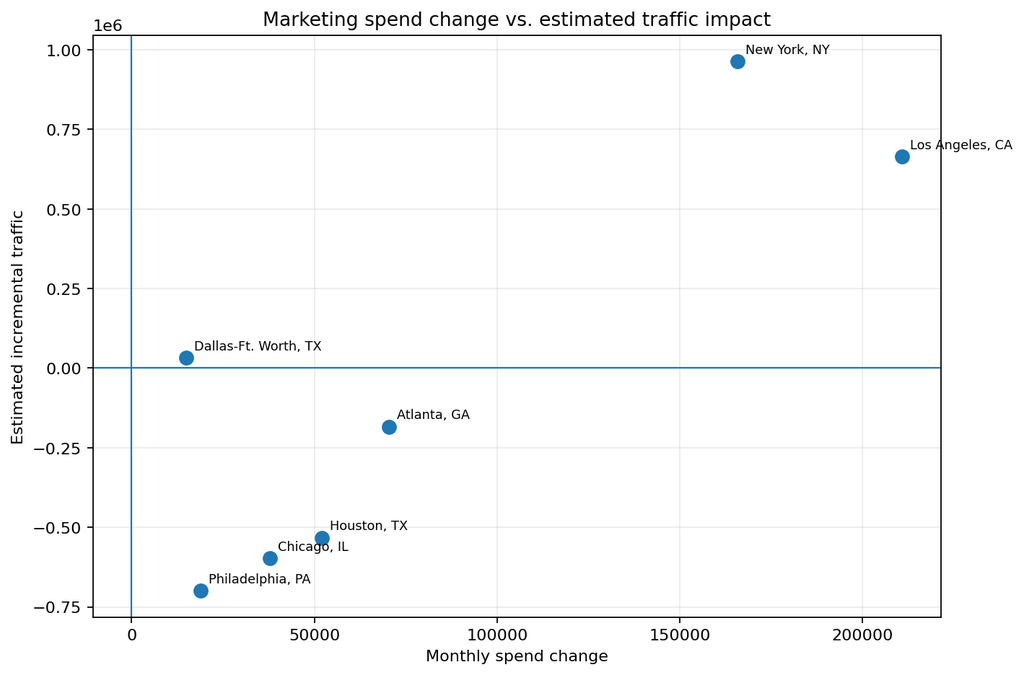

Marketing spend change versus estimated incremental traffic

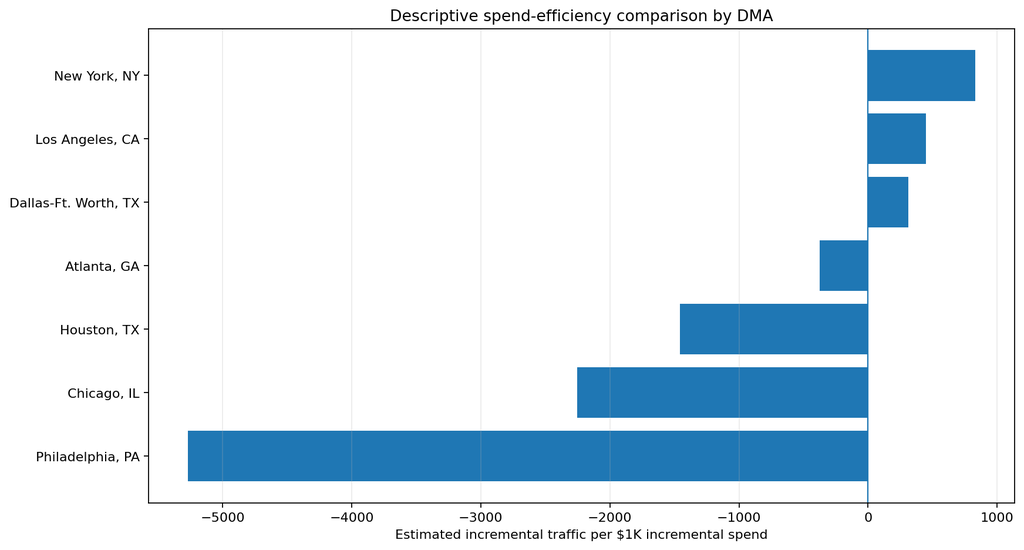

Descriptive traffic impact per $1K incremental spend

### Spend / impact relationships

| Relationship | Spend_Metric | Impact_Metric | N | Pearson_R | Pearson_P_Value | Spearman_Rho | Spearman_P_Value |
| --- | --- | --- | --- | --- | --- | --- | --- |
| Spend Change vs Incremental Traffic | Monthly_Spend_Change | Incremental_Traffic_Mean | 7 | 0.850 | 0.015 | 0.607 | 0.148 |
| Spend % Change vs Incremental Traffic | Monthly_Spend_Change_Pct | Incremental_Traffic_Mean | 7 | 0.485 | 0.270 | 0.500 | 0.253 |
| Spend % Change vs Relative Lift | Monthly_Spend_Change_Pct | Relative_Lift_Median | 7 | 0.557 | 0.194 | 0.571 | 0.180 |
| Post Spend Level vs Incremental Traffic | Post_Monthly_Spend_Mean | Incremental_Traffic_Mean | 7 | 0.882 | 0.009 | 0.643 | 0.119 |
| Incremental Post Spend vs Incremental Traffic | Incremental_Post_Spend | Incremental_Traffic_Mean | 7 | 0.850 | 0.015 | 0.607 | 0.148 |
| Incremental Post Spend vs Relative Lift | Incremental_Post_Spend | Relative_Lift_Median | 7 | 0.816 | 0.025 | 0.643 | 0.119 |

### DMA-level spend and impact

| DMA | Pre_Monthly_Spend_Mean | Pre_Total_Spend | Pre_Month_Count | Post_Monthly_Spend_Mean | Post_Total_Spend | Post_Month_Count | Monthly_Spend_Change | Monthly_Spend_Change_Pct | Incremental_Post_Spend | Spend_Direction | Post_Spend_Share | Incremental_Traffic_Mean | Incremental_Traffic_Median | Impact_Lower_95 | Impact_Upper_95 | Probability_Positive | Probability_Negative | Relative_Lift_Median | Absolute_Impact | Impact_Direction | Impact_Per_Incremental_Spend_Dollar | Impact_Per_Incremental_Spend_1K | Incremental_Spend_Share | Spend_Weighted_Impact | Spend_Weighted_Relative_Lift | Spend_Change_Rank | Spend_Change_Pct_Rank | Impact_Rank | Efficiency_Rank |
| --- | --- | --- | --- | --- | --- | --- | --- | --- | --- | --- | --- | --- | --- | --- | --- | --- | --- | --- | --- | --- | --- | --- | --- | --- | --- | --- | --- | --- | --- |
| Los Angeles, CA | 205272.727 | 2258000 | 11 | 416142.857 | 2913000 | 7 | 210870.130 | 1.027 | 1476090.909 | Increased | 0.206 | 664229.658 | 683786.091 | -315018.293 | 1569172.741 | 0.919 | 0.081 | 0.069 | 664229.658 | Positive | 0.450 | 449.992 | 0.369 | 136838.826 | 0.014 | 1.0 | 1.0 | 2.0 | 2.0 |
| New York, NY | 452272.727 | 4975000 | 11 | 618000.000 | 4326000 | 7 | 165727.273 | 0.366 | 1160090.909 | Increased | 0.306 | 963299.091 | 980620.508 | -1317675.599 | 3151633.196 | 0.814 | 0.186 | 0.051 | 963299.091 | Positive | 0.830 | 830.365 | 0.290 | 294712.296 | 0.016 | 2.0 | 3.0 | 1.0 | 1.0 |
| Atlanta, GA | 95000.000 | 1045000 | 11 | 165428.571 | 1158000 | 7 | 70428.571 | 0.741 | 493000.000 | Increased | 0.082 | -184005.045 | -181964.427 | -800638.647 | 441178.743 | 0.270 | 0.730 | -0.040 | 184005.045 | Negative | -0.373 | -373.235 | 0.123 | -15069.154 | -0.003 | 3.0 | 2.0 | 4.0 | 4.0 |
| Houston, TX | 146727.273 | 1614000 | 11 | 198857.143 | 1392000 | 7 | 52129.870 | 0.355 | 364909.091 | Increased | 0.098 | -532485.581 | -520859.131 | -1491028.785 | 374193.181 | 0.121 | 0.879 | -0.072 | 532485.581 | Negative | -1.459 | -1459.228 | 0.091 | -52420.080 | -0.007 | 4.0 | 4.0 | 5.0 | 5.0 |
| Chicago, IL | 196636.364 | 2163000 | 11 | 234571.429 | 1642000 | 7 | 37935.065 | 0.193 | 265545.455 | Increased | 0.116 | -597896.806 | -622452.717 | -1856604.340 | 778068.884 | 0.183 | 0.817 | -0.079 | 597896.806 | Negative | -2.252 | -2251.580 | 0.066 | -69430.450 | -0.009 | 5.0 | 5.0 | 6.0 | 6.0 |
| Philadelphia, PA | 164909.091 | 1814000 | 11 | 183857.143 | 1287000 | 7 | 18948.052 | 0.115 | 132636.364 | Increased | 0.091 | -698524.387 | -708481.940 | -1292849.392 | -29386.765 | 0.021 | 0.979 | -0.125 | 698524.387 | Negative | -5.266 | -5266.462 | 0.033 | -63578.563 | -0.011 | 6.0 | 6.0 | 7.0 | 7.0 |
| Dallas-Ft. Worth, TX | 188181.818 | 2070000 | 11 | 203142.857 | 1422000 | 7 | 14961.039 | 0.080 | 104727.273 | Increased | 0.101 | 32589.788 | 23500.780 | -571755.948 | 681439.019 | 0.533 | 0.467 | 0.004 | 32589.788 | Positive | 0.311 | 311.187 | 0.026 | 3277.417 | 0.000 | 7.0 | 7.0 | 3.0 | 3.0 |

## Limitations

1. **Short pre-treatment history.** The primary BSTS models use only about eleven pre-treatment monthly observations. This materially limits the amount of historical information available for estimating control relationships and trend behavior.
2. **Wide posterior uncertainty.** Several DMA- and portfolio-level credible intervals are broad and cross zero, so point estimates should not be interpreted as precise treatment effects.
3. **DMA heterogeneity.** The portfolio aggregate combines materially different DMA responses. A single aggregate effect therefore hides meaningful regional variation.
4. **Placebo limitations.** DMA-level placebo tests were feasible, but the available data did not provide a stable common DMA universe across all placebo dates. No aggregate placebo effect was therefore used as primary evidence.
5. **Spend analysis is associative.** The marketing-spend layer evaluates whether estimated effects align with observed spend changes. It does not isolate a causal marginal effect of one additional dollar of spend.
6. **Potential unobserved confounding.** The framework controls for observed control-DMA trajectories and deterministic time structure, but unmeasured factors that change specifically in treated DMAs could still influence the estimated effects.

## Analytical conclusion

The completed analytical workflow provides evidence that the change in traffic after the intervention was **not uniform across DMAs**. The validated portfolio estimate is approximately **-352,793** incremental visits in the posterior mean, with a positive-effect probability of **40.7%**.

The marketing-spend robustness layer shows a moderate positive Pearson association between absolute spend increases and estimated traffic impact (r=0.850), but the normalized spend-change relationships are weak. The evidence therefore supports a nuanced interpretation: **larger marketing investments were concentrated in some of the more positive DMA outcomes, but the analysis does not establish a consistent marginal spend-response relationship.**

Overall, the results are best interpreted as **directional evidence of heterogeneous DMA-level treatment response with substantial uncertainty**, rather than as a precise estimate of a single portfolio-wide marketing incrementality effect.